# PS1_Rmarkdown_Output_Bi610

Dane Dewees

Fri Oct 20 21:04:47 2017

```r
library(tidyverse)
library(magrittr)
library(pander)
```

**Problem 1. Download and examine the data set ‘SticklebackRNAseq.csv’**

*List the variables including their characteristics (i.e. categorical, continuous, response, independent)*

```r
#setwd("/Users/Deweesd/Desktop/Advanced_Stats_with_R")
#getwd

# Read in dataset
RNA_data <- read.table("HW_RNAseq.csv", header = TRUE, sep = ",")


# setting categorical (independent) vairables
Cat_variable <- data.frame(RNA_data[,1:4])


# setting response variables
response_variable <- data.frame(RNA_data[,5:14])
```

*Examine each continuous variable to determine its distribution using histograms, and put these into a single, multi-panel figure.*

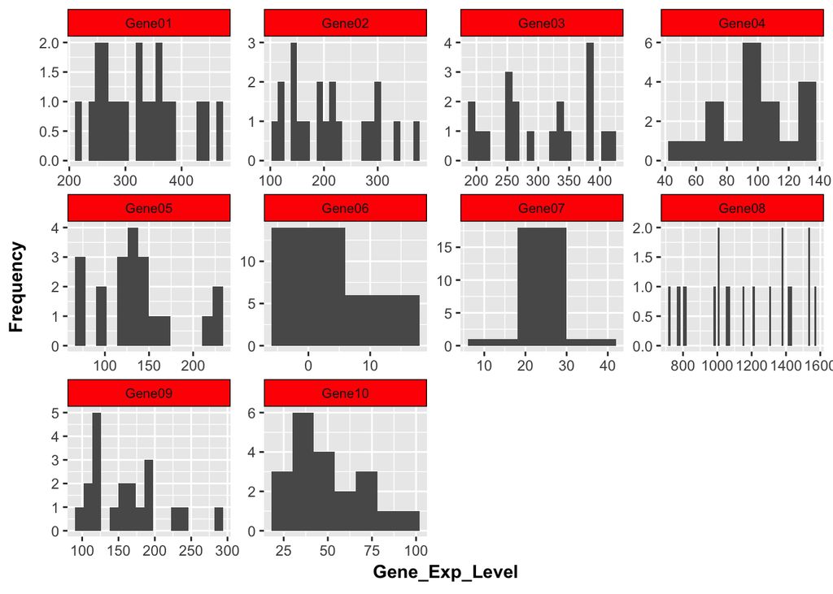

```r
library(ggplot2)
# creating a new orientation of data set that compiles rows to colums
converted_RNA_seq_data <- reshape2::melt(response_variable)
# plotting each gene column via histagram

# setting value as an representation of gene expression levels
ggplot(data = converted_RNA_seq_data, aes(value)) +

  # Setting variable to be the header title "gene" and its corresponding number
  facet_wrap(~variable, scales = 'free') +

  # setting width to 12 for each histogram
  geom_histogram(binwidth = 12) +

  # adjusting the theme of each figure by adjusting the text size, colors, etc.
  theme(strip.text.x = element_text(size = 8, angle = 0),
        strip.text.y = element_text(size = 10, face = "bold"),
        strip.background = element_rect(colour = "black", fill = "red")) +

  # adding labels to both X and Y variables
labs(x=expression(bold("Gene_Exp_Level")), y=expression(bold("Frequency")))
```

*Transform all original continuous variables to z-scores and plot the distribution for just two genes.*

```r
# Transform all original continuous variables to z-scores and plot the distribution for just two genes

response_variable$gene_1_z_score <- (response_variable$Gene01-mean(response_variable$Gene01)) / sd(response_variable$Gene01)
response_variable$gene_2_z_score <- (response_variable$Gene02-mean(response_variable$Gene02)) / sd(response_variable$Gene02)
response_variable$gene_3_z_score <- (response_variable$Gene03-mean(response_variable$Gene03)) / sd(response_variable$Gene03)
response_variable$gene_4_z_score <- (response_variable$Gene04-mean(response_variable$Gene04)) / sd(response_variable$Gene04)
response_variable$gene_5_z_score <- (response_variable$Gene05-mean(response_variable$Gene05)) / sd(response_variable$Gene05)
response_variable$gene_6_z_score <- (response_variable$Gene06-mean(response_variable$Gene06)) / sd(response_variable$Gene06)
response_variable$gene_7_z_score <- (response_variable$Gene07-mean(response_variable$Gene07)) / sd(response_variable$Gene07)
response_variable$gene_8_z_score <- (response_variable$Gene08-mean(response_variable$Gene08)) / sd(response_variable$Gene08)
response_variable$gene_9_z_score <- (response_variable$Gene09-mean(response_variable$Gene09)) / sd(response_variable$Gene09)
response_variable$gene_10_z_score <- (response_variable$Gene10-mean(response_variable$Gene10)) / sd(response_variable$Gene10)
```

*Plot Distribution of Z score for Gene 1/2*

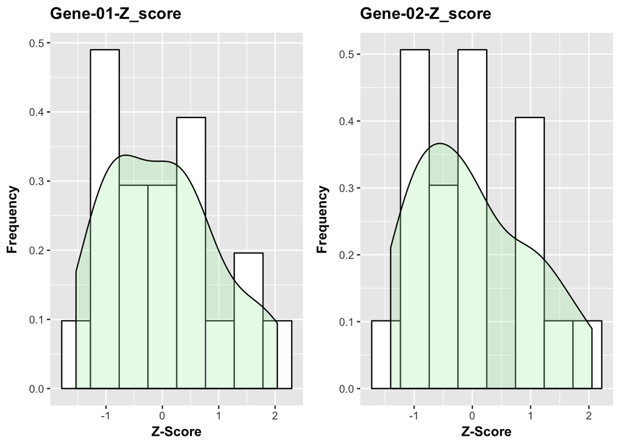

```r
Gene_1_Z_Hist <- ggplot(data = response_variable, aes(gene_1_z_score)) +
    # adding density layover to histogram and setting color parameters
  geom_histogram(aes(y=..density..), colour="black", fill="white", bins = 8) +
   # adjusting transparancy to hist_density
  geom_density(alpha=.3, fill = "darkseagreen2") +
           # adding labels
          labs(x=expression(bold("Z-Score")), y=expression(bold("Frequency")), title=expression(bold("Gene-01-Z_score")))

# setting ggplot to a vector so I can call it when plotting in same plane
Gene_2_Z_Hist <- ggplot(data = response_variable, aes(gene_2_z_score)) +
  # adding density layover to histogram and setting color parameters
  geom_histogram(aes(y=..density..), colour="black", fill="white", bins = 8) +
  # adjusting transparancy to hist_density
  geom_density(alpha=.3, fill = "darkseagreen2") +
  # adding labels
  labs(x=expression(bold("Z-Score")), y=expression(bold("Frequency")), title=expression(bold("Gene-02-Z_score")))

#setting package so I can plot both histograms side by side.
require(gridExtra)
grid.arrange(Gene_1_Z_Hist, Gene_2_Z_Hist, ncol=2)
```

Create boxplots of the original data and the z-scores for these two genes, split by population, treatment and sex. Use colors in your figures. Again, make a single, multi-panel figure.

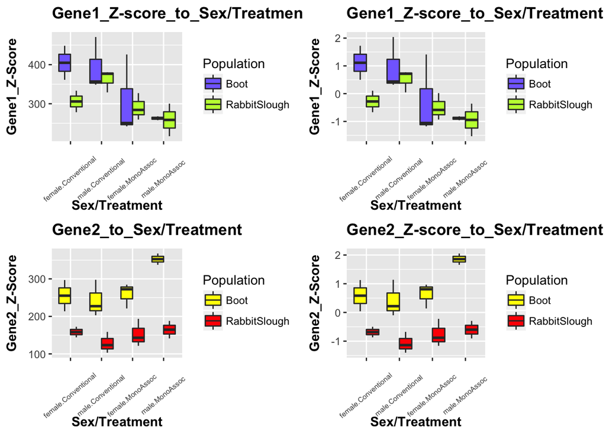

```r
RNA_data$gene1_zscore <- response_variable$gene_1_z_score

RNA_data$gene2_zscore <- response_variable$gene_2_z_score

# using interaction to categorize and filter through all possible combonation of sex and treatment levels
RNA_data$sex_treamtment_combination <- interaction(RNA_data$Sex, RNA_data$Treatment)

Gene_1_boxplot_Z <- ggplot(data = RNA_data, aes(y = gene1_zscore, x = sex_treamtment_combination, fill=Population)) + geom_boxplot() + scale_fill_manual(values=c("slateblue1", "olivedrab1")) + theme(axis.text.x = element_text(angle = 40, vjust = 0.3, size = 6)) +
  labs(x=expression(bold("Sex/Treatment")), y=expression(bold("Gene1_Z-Score")), title=expression(bold("Gene1_Z-score_to_Sex/Treatment")))

Gene_2_boxplot_Z <- ggplot(data = RNA_data, aes(y = gene2_zscore, x = sex_treamtment_combination, fill=Population)) + geom_boxplot() + scale_fill_manual(values=c("yellow1", "red1")) + theme(axis.text.x = element_text(angle = 40, vjust = 0.3, size = 6)) +
  labs(x=expression(bold("Sex/Treatment")), y=expression(bold("Gene2_Z-Score")), title=expression(bold("Gene2_Z-score_to_Sex/Treatment")))

Gene_1_boxplot <- ggplot(data = RNA_data, aes(y = Gene01, x = sex_treamtment_combination, fill=Population)) + geom_boxplot() + scale_fill_manual(values=c("slateblue1", "olivedrab1")) + theme(axis.text.x = element_text(angle = 40, vjust = 0.3, size = 6)) +
  labs(x=expression(bold("Sex/Treatment")), y=expression(bold("Gene1_Z-Score")), title=expression(bold("Gene1_Z-score_to_Sex/Treatment")))

Gene_2_boxplot <- ggplot(data = RNA_data, aes(y = Gene02, x = sex_treamtment_combination, fill=Population)) + geom_boxplot() + scale_fill_manual(values=c("yellow1", "red1")) + theme(axis.text.x = element_text(angle = 40, vjust = 0.3, size = 6)) +
  labs(x=expression(bold("Sex/Treatment")), y=expression(bold("Gene2_Z-Score")), title=expression(bold("Gene2_to_Sex/Treatment")))


require(gridExtra)
grid.arrange(Gene_1_boxplot, Gene_1_boxplot_Z, Gene_2_boxplot, Gene_2_boxplot_Z)
```

Calculate descriptive statistics (mean, variance, standard deviation) for each population for each variable, for each treatment for each variable, and for each sex for each variable. Compile these into a table.

```r
Gene1_summary <- group_by(RNA_data, Sex, Treatment, Population) %>%
  summarise_at("Gene01", .funs = c(Variance = "var", Mean="mean", SD="sd")) %>%
  write.csv('Gene_1_Summary_Stats.csv', row.names = F)

# setting table for mean, variance, and SD for the categorical vairables
Gene2_summary <- group_by(RNA_data, Sex, Treatment, Population) %>%
  summarise_at("Gene02", .funs = c(Variance = "var", Mean="mean", SD="sd")) %>%
  write.csv('Gene_2_Summary_Stats.csv', row.names = F)

# setting table for mean, variance, and SD for the categorical vairables
Gene3_summary <- group_by(RNA_data, Sex, Treatment, Population) %>%
  summarise_at("Gene03", .funs = c(Variance = "var", Mean="mean", SD="sd")) %>%
  write.csv('Gene_3_Summary_Stats.csv', row.names = F)

# setting table for mean, variance, and SD for the categorical vairables
Gene4_summary <- group_by(RNA_data, Sex, Treatment, Population) %>%
  summarise_at("Gene04", .funs = c(Variance = "var", Mean="mean", SD="sd")) %>%
  write.csv('Gene_4_Summary_Stats.csv', row.names = F)

# setting table for mean, variance, and SD for the categorical vairables
Gene5_summary <- group_by(RNA_data, Sex, Treatment, Population) %>%
  summarise_at("Gene05", .funs = c(Variance = "var", Mean="mean", SD="sd")) %>%
  write.csv('Gene_5_Summary_Stats.csv', row.names = F)

# setting table for mean, variance, and SD for the categorical vairables
Gene6_summary <- group_by(RNA_data, Sex, Treatment, Population) %>%
  summarise_at("Gene06", .funs = c(Variance = "var", Mean="mean", SD="sd")) %>%
  write.csv('Gene_6_Summary_Stats.csv', row.names = F)

# setting table for mean, variance, and SD for the categorical vairables
Gene7_summary <- group_by(RNA_data, Sex, Treatment, Population) %>%
  summarise_at("Gene07", .funs = c(Variance = "var", Mean="mean", SD="sd")) %>%
  write.csv('Gene_7_Summary_Stats.csv', row.names = F)

# setting table for mean, variance, and SD for the categorical vairables
Gene8_summary <- group_by(RNA_data, Sex, Treatment, Population) %>%
  summarise_at("Gene08", .funs = c(Variance = "var", Mean="mean", SD="sd")) %>%
  write.csv('Gene_8_Summary_Stats.csv', row.names = F)

# setting table for mean, variance, and SD for the categorical vairables
Gene9_summary <- group_by(RNA_data, Sex, Treatment, Population) %>%
  summarise_at("Gene09", .funs = c(Variance = "var", Mean="mean", SD="sd")) %>%
  write.csv('Gene_9_Summary_Stats.csv', row.names = F)

# setting table for mean, variance, and SD for the categorical vairables
Gene10_summary <- group_by(RNA_data, Sex, Treatment, Population) %>%
  summarise_at("Gene10", .funs = c(Variance = "var", Mean="mean", SD="sd")) %>%
  write.csv('Gene_10_Summary_Stats.csv', row.names = F)
```